# HW4

library(tseries) library(xts) library(dplyr) library(forecast)

#Figures

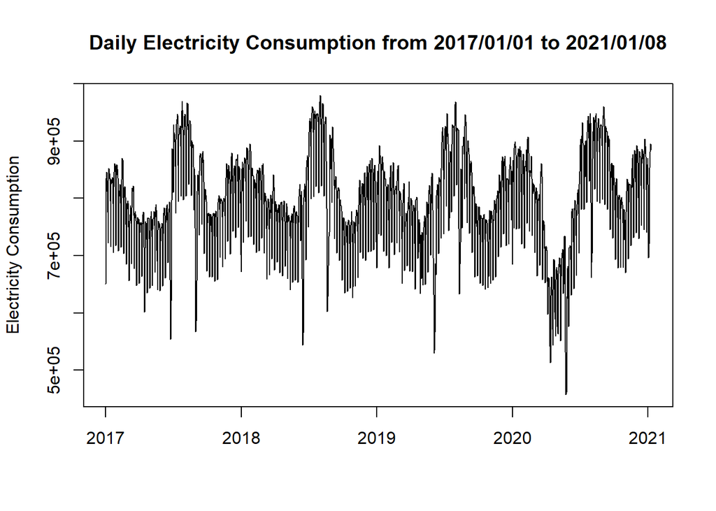

```r
plot(ts_tuketim, ylab= "Electricity Consumption", xlab="", main="Daily Electricity Consumption from 2017/01/01 to 2021/01/08" )
```

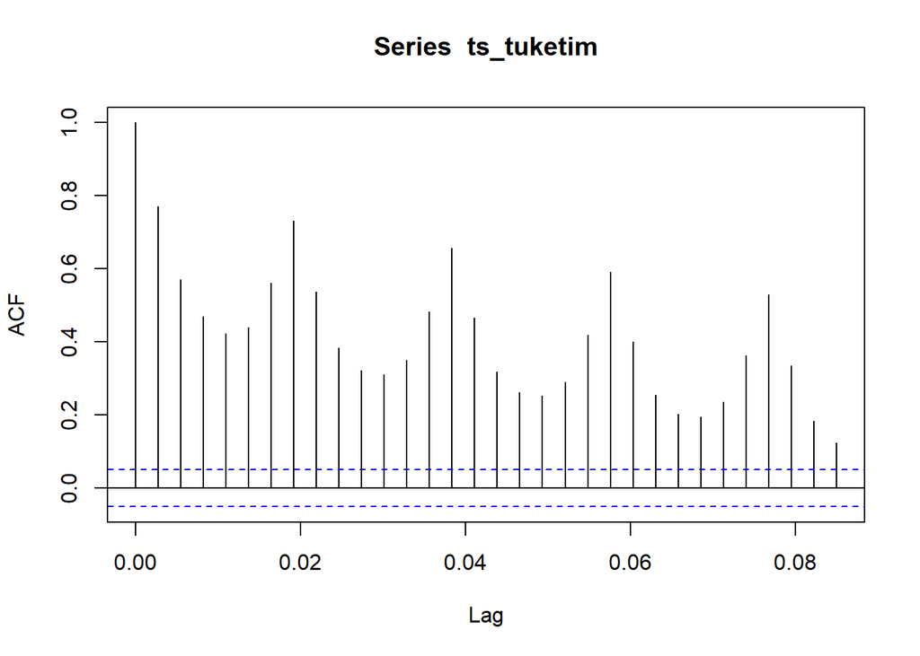

```r
plot(acf(ts_tuketim))
```

Significant autocorrelation at lag 7, (today’s electricity consumption is correlated with the consumption 7 days ago)

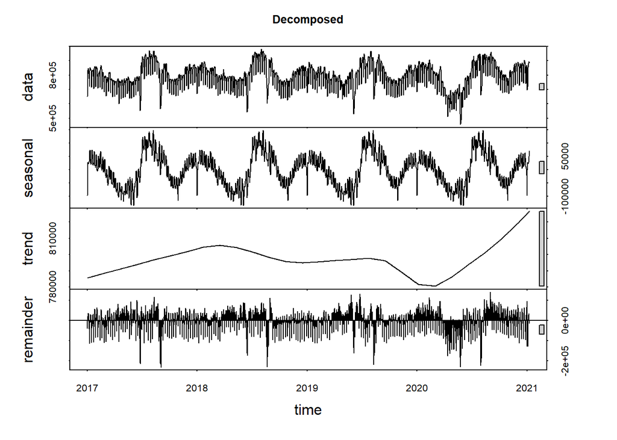

```r
plot(decomp, main="Decomposed")
```

We have significant seasonality between the same quarters of multiple years

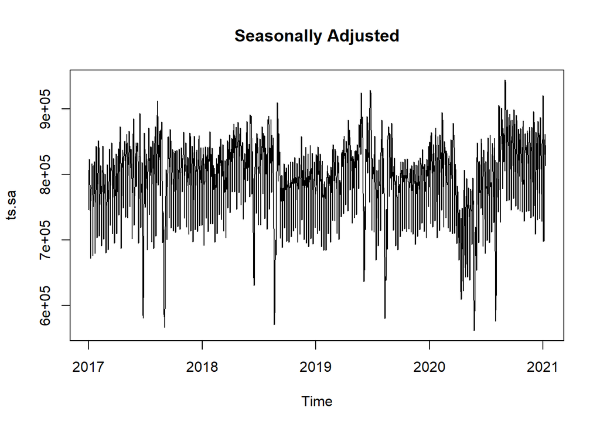

```r
plot(ts.sa, main="Seasonally Adjusted")
```

#Appendix Tuketim <- read.table(file = “C:\Users\bjkse\Desktop\Tuketim.csv”, sep = “,”, dec = “,”) Tuketim <- as.data.frame.matrix(Tuketim) names(Tuketim) <- Tuketim[1,] Tuketim <- Tuketim[-1,] Tuketim <- select(Tuketim, -c(2))

Tuketim$Tarih = as.POSIXct(strptime(Tuketim$Tarih, format = “%d.%m.%Y”)) Tuketim$`Tuketim Miktari (MWh)` <- as.numeric(Tuketim$`Tuketim Miktari (MWh)`)

Toplam <- aggregate(Tuketim$`Tuketim Miktari (MWh)`, by=list(Tarih=Tuketim$Tarih), FUN=sum)

inds <- seq(as.Date(“2017-01-01”), as.Date(“2021-01-08”), by = “day”) ts_tuketim <- ts(Toplam$x, start = c(2017, as.numeric(format(inds[1], “%j”))), frequency = 365) decomp = stl(ts_tuketim, “periodic”) ts.sa <- seasadj(decomp)